# Examining NK signature genes in SadeFeldman et al single cell data

# 3 Data visualisation

The main aim is to re-generate the UMAP plots in Cursons et al paper. ## PCA We perform PCA, using the highly variable genes.

```r
ss <-
  RunPCA(
  object = ss,
  pc.genes = ss@var.genes,
  do.print = FALSE,
  pcs.print = 1:5,
  genes.print = 5
  )
```

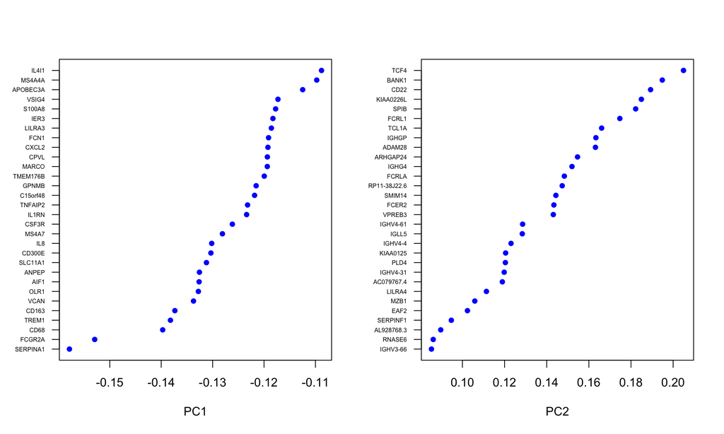

```r
VizPCA(object = ss, pcs.use = 1:2)
```

We select the first 20 PCs for the further analysis such as clustering. We then look at the top genes defining the first 6 PCs.

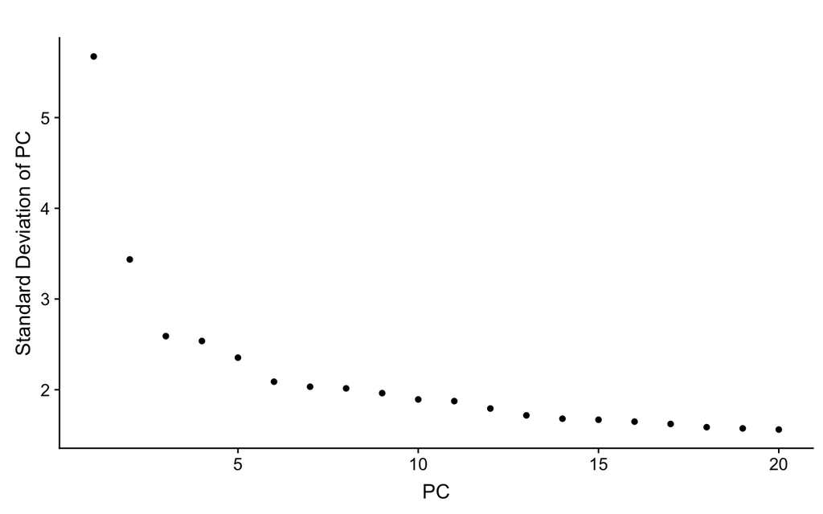

```r
PCElbowPlot(object = ss)
```

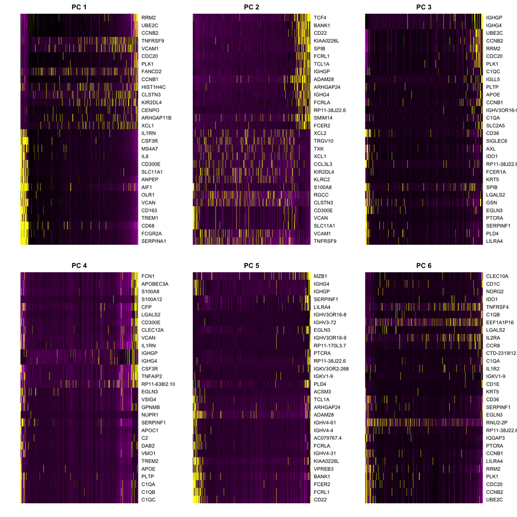

```r
PCHeatmap(ss, pc.use = c(1:6), cells.use = NULL, do.balanced = TRUE)
```

```r
ss <- FindClusters(
  object = ss,
  reduction.type = "pca",
  dims.use = 1:20,
  resolution = 1,
  save.SNN = TRUE,
  n.start = 100,
  # nn.eps = 0.1,
  print.output = FALSE)
```

## 3.1 UMAP

To select the values for minDist and nNeighbors argument in UMAP plot, we examined different values for these parameters and assessed the resultant UMAP plots. We have commented the codes below as these take quite some time to run; you can uncomment them though and run to see the resultant figures.

```r
# checkG <- c(
#   "FCGR3A", "CD4", "CD3D", "CD3E",
#   "NCR1",  "NCAM1",
#   "KLRF1", "XCL1", "XCL2",
#   "GZMB", "FASLG", "CTSW")
#
# set.seed(100)
# currentExpr <- ss@data[row.names(ss@data) %in% checkG, ]
#
# minDist <- c(0.001, 0.01, 0.05, 0.1, 0.2, 0.3, 0.4, 0.5, 0.6, 0.7)
# nNeighbors <- c(30, 50, 70, 100)
#
# pdf(paste0(outPath, "SadeFeldman_UMAP_diff_minDist_nNeighbours.pdf"), width = 8, height = 8)
# for(i in minDist){
#  for(j in nNeighbors){
#
#    ss <- RunUMAP(
#     object = ss,
#     reduction.use = "pca",
#     dims.use = 1:20,
#     min_dist = i,
#     n_neighbors = j
#     )
#
#   umapData <- data.frame(ss@dr$umap@cell.embeddings)
#   umapDataGenes <- data.frame(cbind(umapData, t(currentExpr)))
#   umapDataGenesLong <- tidyr::gather(umapDataGenes, Genes, LogTPM, CD4:FCGR3A)
#
#   umapDataGenesLongArrange <- umapDataGenesLong %>%
#   group_by(Genes) %>%
#   arrange(LogTPM) %>%
#   ungroup() %>%
#   data.frame()
#
#   umapDataGenesLongArrange$Genes <- factor(umapDataGenesLongArrange$Genes ,
#   levels = checkG)
#
#   p <-
#     ggplot(umapDataGenesLongArrange, aes(UMAP1 , UMAP2, colour = LogTPM)) +
#     geom_point(size = 0.5) +
#     facet_wrap( ~ Genes, ncol = 3) +
#     scale_color_gradient(low = "darkorchid4", high = "yellow") +
#     theme_dark() +
#     ggtitle(paste("minDist =", i, "; nNeighbour =", j))
#
#   print(p)
#
#  }
# }
# dev.off()
```

We look at genes expressed in different blood cell types in order to find out which cell belongs to which cell type. This reproduce the second part of **Figure 3** in Cursons et al paper.

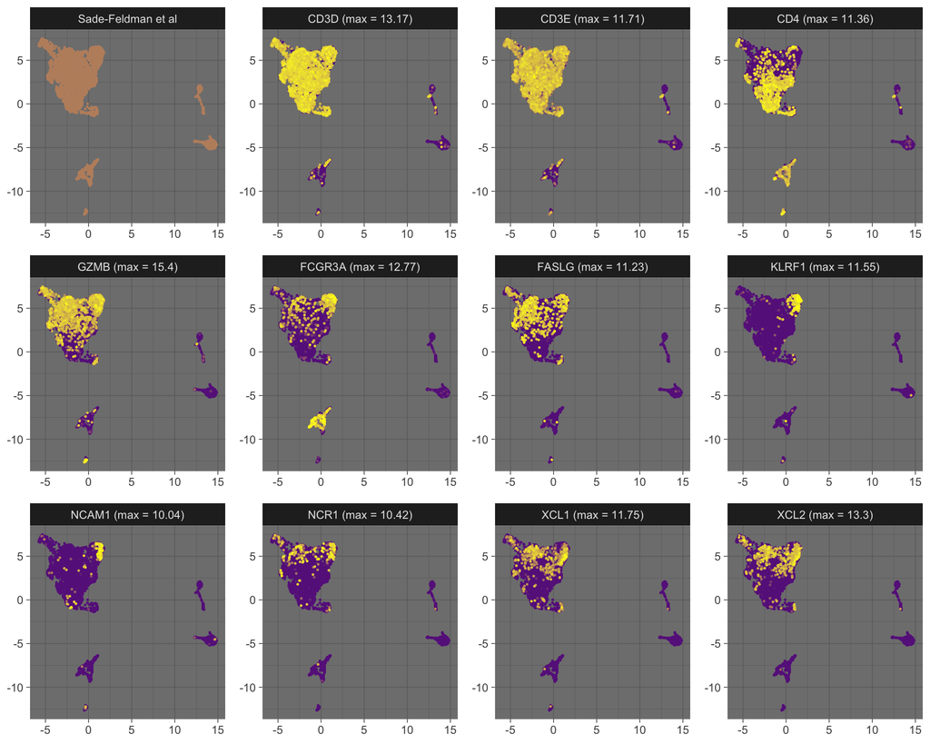

```r
checkG <- c(
  "CTSW",
  "CD4",
  "CD3D",
  "CD3E",
  "FCGR3A",
  "GZMB",
  "NCR1",
  "NCAM1",
  "KLRF1",
  "XCL1",
  "XCL2",
  "FASLG"
  )

set.seed(100)
currentExpr <- ss@data[row.names(ss@data) %in% checkG, ]

i <- 0.1
j <- 30

ss <- RunUMAP(
  object = ss,
  reduction.use = "pca",
  dims.use = 1:20,
  min_dist = i,
  n_neighbors = j
  )

umapData <- data.frame(ss@dr$umap@cell.embeddings)

##-------------- for different genes
umapDataGenes <- data.frame(cbind(umapData, t(currentExpr)))
umapDataGenesLong <- tidyr::gather(umapDataGenes, Genes, LogTPM, 3:14)

umapDataGenesLongArrange <- umapDataGenesLong %>%
group_by(Genes) %>%
arrange(LogTPM) %>%
mutate(maxVal = round(max(LogTPM), 2)) %>%
mutate(minVal = 0) %>%
mutate(GenesMax = paste0(Genes, " (max = ", maxVal, ")")) %>%
ungroup() %>%
data.frame()

  umapDataGenesLongArrange$GenesMax[  umapDataGenesLongArrange$GenesMax == "CTSW (max = 12.01)"] <- "Sade-Feldman et al"

  umapDataGenesLongArrange$LogTPM[  umapDataGenesLongArrange$GenesMax == "Sade-Feldman et al"] <- 0.1

umapDataGenesLongArrange$GenesMax <- factor(umapDataGenesLongArrange$GenesMax ,
levels = c(
  "Sade-Feldman et al", "CD3D (max = 13.17)", "CD3E (max = 11.71)",
  "CD4 (max = 11.36)", "GZMB (max = 15.4)", "FCGR3A (max = 12.77)",
  "FASLG (max = 11.23)", "KLRF1 (max = 11.55)", "NCAM1 (max = 10.04)",
  "NCR1 (max = 10.42)", "XCL1 (max = 11.75)", "XCL2 (max = 13.3)"
  ))

pp <- umapDataGenesLongArrange %>% group_by(GenesMax) %>%
  do(
    plots = ggplot(data = .) + aes(UMAP1 , UMAP2, colour = LogTPM) +
  geom_point(size = 0.3) +
  facet_wrap( ~ GenesMax, ncol = 3) +
  scale_color_gradient(low = "darkorchid4", high = "yellow") +
  theme_dark() +
      theme(
        legend.position = "none",
    axis.title = element_blank()
    # , axis.text = element_blank()
      ))

gridExtra::grid.arrange(
  pp$plots[[1]],
  pp$plots[[2]],
  pp$plots[[3]],
  pp$plots[[4]],
  pp$plots[[5]],
  pp$plots[[6]],
  pp$plots[[7]],
  pp$plots[[8]],
  pp$plots[[9]],
  pp$plots[[10]],
  pp$plots[[11]],
  pp$plots[[12]],
  nrow = 3)
```

We generate a UMAP plot, where all genes are coloured the same.

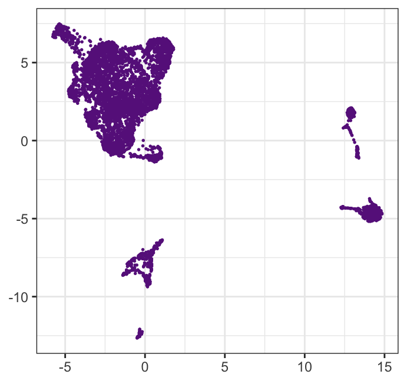

```r
ggplot(data = umapData , aes(UMAP1 , UMAP2)) +
  geom_point(size = 0.3, colour = "darkorchid4") +
  theme_bw() +
  theme(
  axis.title = element_blank()
  # axis.text = element_blank()
  )
```

# 4 Session information